# Insert chapter 2 title here

### Diagnostic plots

We can check diagnostic plots by using the function **plot**:

**Q-Q** plots: these plots reveal the information on the normality of the data.

**Residuals and Fitted** plots: the variances need to be homogenous and this can be checked through these plots.

**Residuals and Leverage** plots: thses plots are used to show the influential cases by using the Cook’s distance line.

**Scale-Location** plots: to check whether the residuals are spread equally along the predictor range, we can make use of these plots.

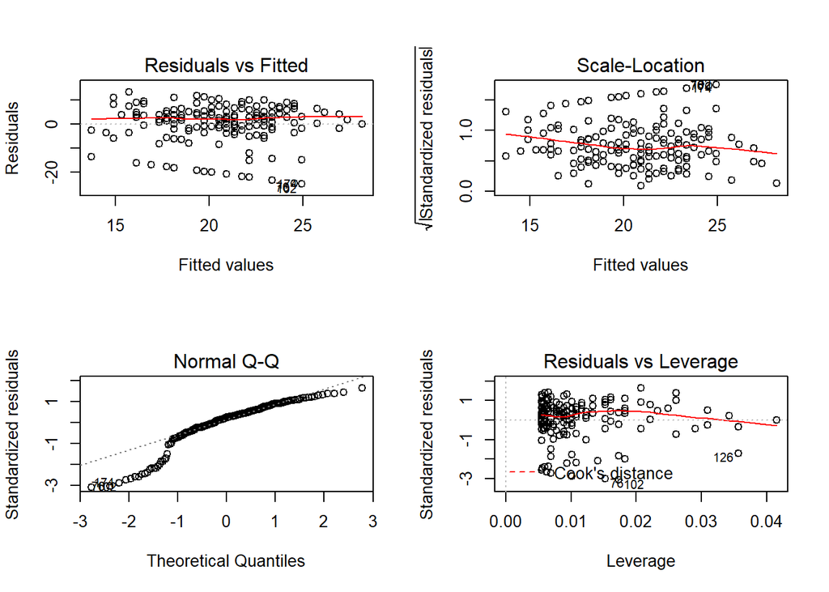

```r
layout(matrix(c(1,2,3,4),2,2))
plot(model2)
```

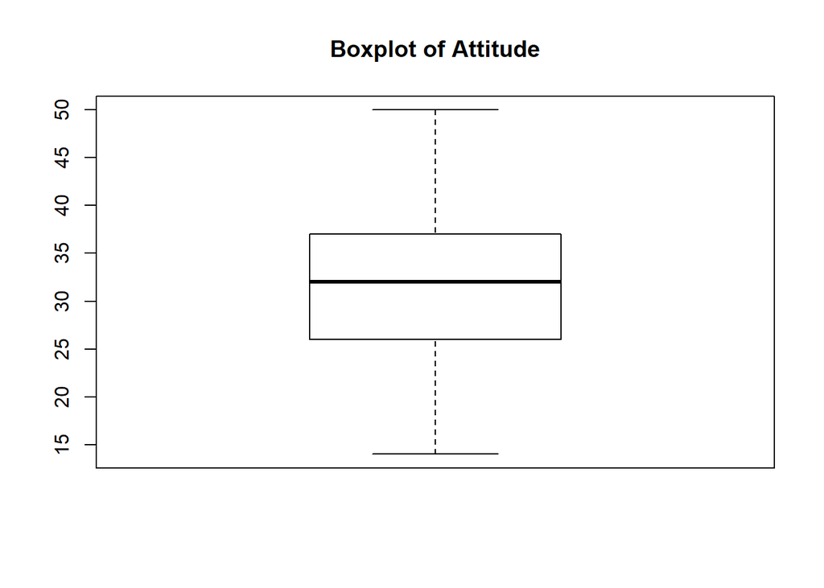

```r
boxplot(attitude)
title('Boxplot of Attitude')
```